# Biogeografía

Práctica: Mapeo de las Áreas de Importancia para los Mamíferos Marinos de México

[figure not shown]

# Objetivo

Inspeccionar y mapear las Áreas de Importancia para Mamíferos Marinos (IMMA, por sus siglas en inglés) de la IUCN que se encuentran en México. El mapa final debe incluir leyenda, flecha norte, escala, marco, cuadrícula y coordenadas geográficas.

# Descripción

En esta práctica, el estudiante organizará un proyecto SIG en QGIS, cargará las capas vectoriales de México, de la Zona Económica Exclusiva (ZEE) y de las IMMAs del mundo, y recortará las IMMAs con la ZEE mediante una intersección. Después configurará la simbología (IMMAs categorizadas, ZEE sin relleno y México en un tono tenue) y diseñará una composición de impresión con todos los elementos cartográficos básicos. Por último, escribirá un breve reporte que incluirá el mapa final y una reflexión sobre las IMMAS en México.

# Datos

Descargue los datos [aquí](https://drive.google.com/drive/folders/1RmSDHkCFwnmbv5VUJcVdnWVxf2-RMIHA?usp=sharing). Descargue los archivos `.shp` y todos sus archivos accesorios (`.dbf`, `.shx`, `.prj`, etc.).

# Pasos generales

1. Crear directorio de trabajo y descargar los datos.
2. Generar proyecto en QGIS.
3. Cargar y examinar los datos.
4. Obtener la intersección IMMAs–ZEE.
5. Configurar la simbología.
6. Crear la composición de mapa.
7. Redactar el informe.

# Instrucciones

### 1. Crear la estructura de carpetas

- Cree una carpeta llamada **MAPA-IMMAS-MEXICO**.
- Dentro de ella cree tres subcarpetas: **DATOS**, **PROYECTO** y **FIGURAS**.
- Use **DATOS** para los archivos de entrada y el resultado de la intersección, **PROYECTO** para el `.qgz` y **FIGURAS** para las capturas de pantalla y el mapa exportado.
- Descargue los datos y guárdelos en **DATOS**.

### 2. Generar proyecto en QGIS

- Abra QGIS y cree un proyecto nuevo.
- Guárdelo como **MAPA-IMMAS-MEXICO.qgz** dentro de la carpeta **PROYECTO**.

### 3. Cargar y examinar los datos

- Arrastre los tres archivos `.shp` desde la carpeta **DATOS** al **Panel de capas** (o use el **Administrador de fuentes de datos**). QGIS asigna colores aleatorios de forma automática.

[figure not shown]

Cargar capas vectoriales.

- Añada un mapa base desde **Web → QuickMapServices**. Si no aparece el menú, instale el complemento en **Complementos → Administrar e instalar complementos**.
- Haga acercamientos y alejamientos con la rueda del ratón.
- Active y desactive las capas con las casillas del **Panel de capas**.
- Explore las IMMAs del mundo y después concéntrese en las que recaen en territorio nacional.

[figure not shown]

Inspeccionar las capas.

### 4. Obtener la intersección

[figure not shown]

Intersección entre IMMAs y ZEE.

- Guarde la capa en **DATOS**:
  - clic derecho en “Intersección” → **Exportar → Guardar objetos como…**;
  - **Formato**: `GeoPackage`;
  - en **Nombre de archivo**, use el botón `…` para elegir la carpeta **DATOS** y el nombre `interseccion`;
  - clic en **Aceptar**.

[figure not shown]

Guardar la capa de intersección.

### 5. Simbología

Las IMMAs tendrán colores categorizados, la ZEE un relleno transparente y México un color tenue que no compita con las IMMAs.

- **Interseccion** (doble clic en la capa → **Simbología**):
  - cambiar de **Símbolo único** a **Categorizado**;
  - **Valor**: `Title`;
  - **Rampa de color**: `Random colours`;
  - clic en **Clasificar** y **Aceptar**.

[figure not shown]

Simbología de la capa de intersección.

- **México** (**Simbología**): dejar **Símbolo único**, clic en **Relleno simple** y elegir un color de baja intensidad.

[figure not shown]

Simbología del polígono de México.

- **ZEE_MX** (**Simbología**): dejar **Símbolo único**, clic en **Relleno simple**:
  - **Color de relleno** → menú desplegable (triángulo) → **Relleno transparente**;
  - **Ancho de trazo**: `1 mm`.

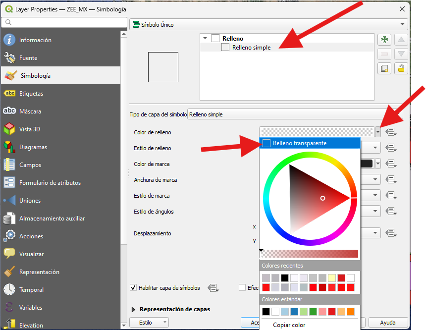

Simbología de la ZEE.

- Ordene las capas en el **Panel de capas**: `Interseccion` arriba, después `ZEE_MX`, después México y el mapa base al fondo.

### 6. Composición de mapa

El mapa en la composición se verá tal como esté en la vista principal de QGIS, así que ajuste antes el encuadre.

- Clic en **Nueva composición de impresión** (menú **Proyecto**), nombre `MAPA-IMMAS` y **Aceptar**.

[figure not shown]

Nueva composición e interfaz.

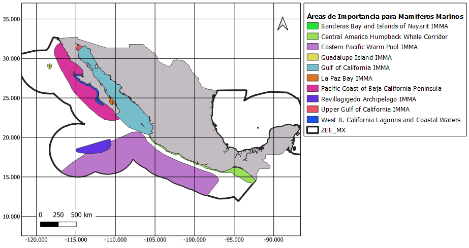

Ejemplo de mapa terminado.

- Exporte desde **Composición → Exportar como imagen…**, nombre `MAPA-IMMAs.png` en **FIGURAS**, resolución `600 ppp`.

### 7. ¿Qué debo entregar?

Un reporte breve (**350 palabras máximo, 325 mínimo**) que incluya:

1. Descripción de lo realizado (breve, debe ser la sección más corta; no copie y pegue los pasos).
2. Imagen de alta calidad del mapa final `MAPA-IMMAs.png`.
3. Análisis del mapa (debe ser la sección más amplia). Considere explícitamente: cuántas IMMAs recaen en la ZEE de México y dónde se ubican, qué diferencia hay entre las IMMAs completas y las recortadas por la ZEE, cuáles mamiferos marinos se distribuyen en esas zonas, qué utilidad crees que tiene este mapa para la conservación y gestión de los mamíferos marinos en México.